# Statistik und Qualität - Ausarbeitung der ersten Übung

# C) Offene Untersuchung

## **C-1)** Das komma-separierte File „Unternehmensumsaetze.csv“ enthält Daten zu den 97 weltweit größten und börsennotierten Konzernen. In dieser Tabelle sind die Umsätze und Gewinne in Mrd. $ angegeben. Untersuche die Daten mit den bekannten Methoden. Beantworte damit Fragen, wie z.B.: „Wie verteilen sich die Unternehmen auf Länder und Branchen?“, „Wie verteilen sich Gewinne, Umsätze und Mitarbeiter?“, „Welche Branchen generieren besonders viele Umsätze oder Gewinne pro Mitarbeiter?“, und andere mehr. Verwende dazu geeignete Häufigkeitsdarstellungen und Lageparameter. Lege eine passende Regressionsgerade durch die Merkmale „Mitarbeiter“ und „Gewinn“. Wo gibt es Ausreißer. Erkundige Dich nach der Lorenzkurve und wende sie auf die Werte der Merkmale „Umsätze“ und „Mitarbeiter“ an.

**Verteilung der Unternehmen nach den Branchen**

```r
Unternehmensumsätze.df <- read.csv("Unternehmensumsaetze.csv", sep = ";", dec = ",", header = TRUE)
```

**Verteilung der Unternehmen nach den jeweiligen Länder in dem das Unternehmen seinen Hauptwohnsitz hat**

```r
Land.df <- data.frame(table(Unternehmensumsätze.df$Land))
names(Land.df) <- c("Staat" , "Anzahl")
Land.df[order(Land.df$Anzahl, decreasing = TRUE),]
```

|  | Staat | Anzahl |
| --- | --- | --- |
| 18 | USA | 31 |
| 20 | Volksrepublik China | 13 |
| 2 | Deutschland | 10 |
| 3 | Frankreich | 9 |
| 7 | Japan | 8 |
| 6 | Italien | 4 |
| 4 | Grossbritannien | 3 |
| 12 | Russland | 3 |
| 5 | Indien | 2 |
| 10 | Niederlande | 2 |

[output cut: 10 more lines]

**Verteilung der Unternehmen nach Branchen**

```r
Branche.df <- data.frame(table(Unternehmensumsätze.df$Branche))
names(Branche.df) <- c("Branche", "Anzahl")
Branche.df[order(Branche.df$Anzahl, decreasing = TRUE),]
```

|  | Branche | Anzahl |
| --- | --- | --- |
| 16 | Oel und Gas | 22 |
| 3 | Banken | 15 |
| 1 | Automobile | 9 |
| 6 | Einzelhandel | 6 |
| 20 | Technologie | 6 |
| 21 | Telekommunikation | 5 |
| 22 | Versicherungen | 5 |
| 23 | Versorger | 5 |
| 14 | Mischkonzern | 3 |
| 17 | Pharmahandel | 3 |

[output cut: 13 more lines]

**Verteilung der Unternehmen nach Hauptsitz**

```r
Hauptsitz.df <- data.frame(table(Unternehmensumsätze.df$Hauptsitz))
names(Hauptsitz.df) <- c("Hauptsitz" , "Anzahl")
Hauptsitz.df[order(Hauptsitz.df$Anzahl, decreasing = TRUE),]
```

|  | Hauptsitz | Anzahl |
| --- | --- | --- |
| 41 | Peking | 12 |
| 40 | Paris | 8 |
| 52 | Tokio | 6 |
| 34 | Muenchen | 4 |
| 33 | Moskau | 3 |
| 37 | New York | 3 |
| 12 | Cincinnati | 2 |
| 20 | Duesseldorf | 2 |
| 28 | London | 2 |
| 43 | Rom | 2 |

[output cut: 50 more lines]

**Aufteilung nach Unternehmensumsätze**

```r
summary(Unternehmensumsätze.df$Umsatz)
```

```
##    Min. 1st Qu.  Median    Mean 3rd Qu.    Max.
##   79.83   98.53  114.30  143.97  146.90  476.29
```

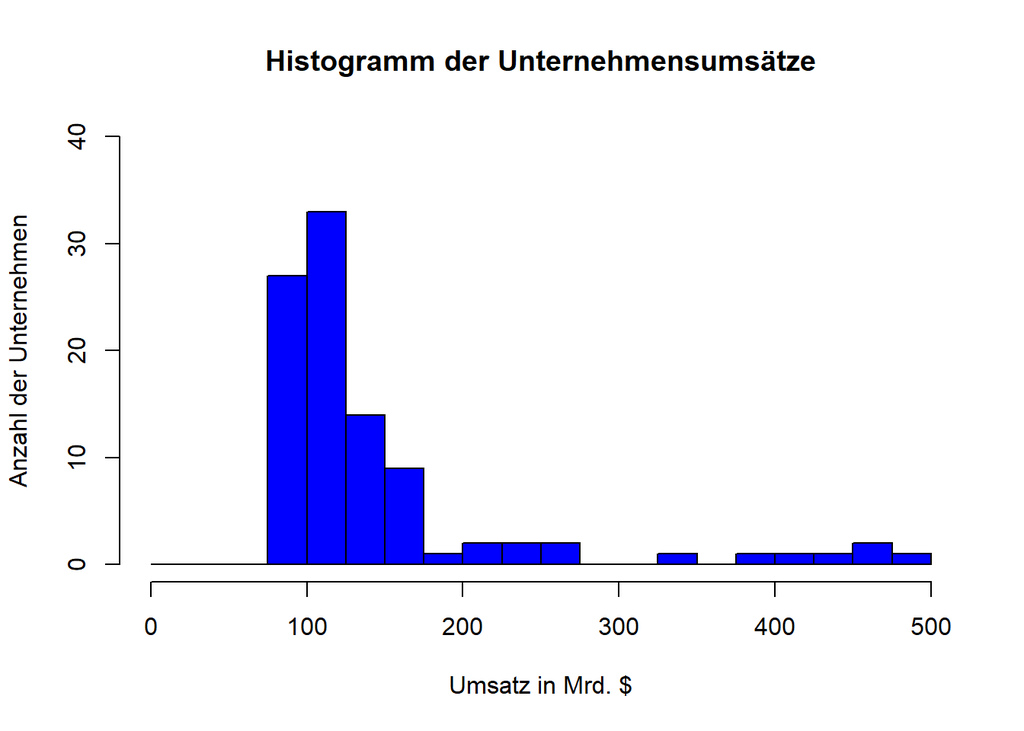

```r
hist(Unternehmensumsätze.df$Umsatz, c(0,25,50,75,100,125,150,175,200,225,250,275,300,325,350,375,400,425,450,475,500), col = "blue", main = "Histogramm der Unternehmensumsätze", xlab = "Umsatz in Mrd. $", ylab = "Anzahl der Unternehmen", ylim = c(0,40))
```

**Aufteilung nach Unternehmensgewinnen**

```r
summary(Unternehmensumsätze.df$Gewinn)
```

```
##    Min. 1st Qu.  Median    Mean 3rd Qu.    Max.
## -12.300   2.700   6.076  10.049  13.700  83.900
```

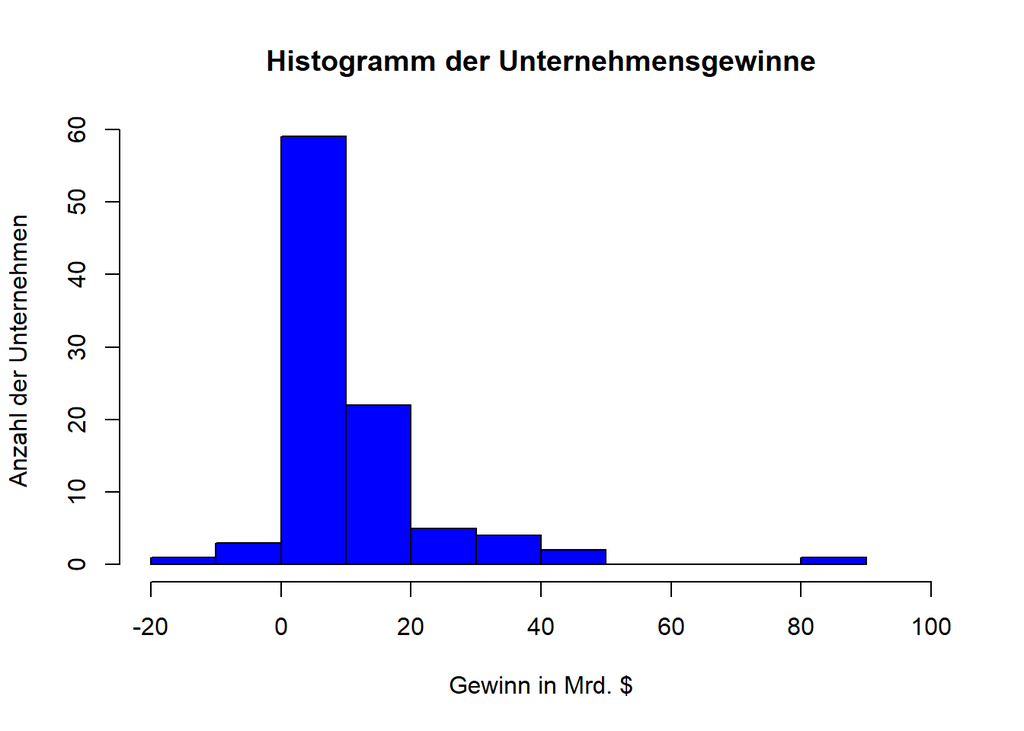

```r
Breaks.vec <- c(-20,-10,0,10,20,30,40,50,60,70,80,90)

hist(Unternehmensumsätze.df$Gewinn, Breaks.vec, main = "Histogramm der Unternehmensgewinne", xlab = "Gewinn in Mrd. $", ylab = "Anzahl der Unternehmen", col = "blue", xlim = c(-20,100))
```

**Sortierung nach Umsatz je Mitarbeiter in $**

```r
Mitarbeit_Bran.vec <- aggregate(Unternehmensumsätze.df$Mitarbeiter, by = list(Branche = Unternehmensumsätze.df$Branche), FUN = sum)

Umsatz_Bran.vec <- aggregate(Unternehmensumsätze.df$Umsatz, by = list(Branche = Unternehmensumsätze.df$Branche), FUN = sum)

Umsatz_Mitarbeit_Bran.df <- data.frame(Bran = Umsatz_Bran.vec$Branche, Ums_Mit = 1000000000*Umsatz_Bran.vec$x/Mitarbeit_Bran.vec$x)

names(Umsatz_Mitarbeit_Bran.df) <- c("Branche", "Umsatz_je_Mitarbeiter")
Umsatz_Mitarbeit_Bran.df[order(Umsatz_Mitarbeit_Bran.df$Umsatz_je_Mitarbeiter, decreasing = TRUE),]
```

|  | Branche | Umsatz_je_Mitarbeiter |
| --- | --- | --- |
| 19 | Rohstoffhandel | 4591305.6 |
| 17 | Pharmahandel | 4130774.1 |
| 18 | Pharmazie | 3462518.6 |
| 13 | Logistik, Bankwesen, Versicherungswesen | 1382954.5 |
| 22 | Versicherungen | 1034492.8 |
| 16 | Oel und Gas | 997392.1 |
| 5 | Chemie | 883562.3 |
| 8 | Finanzdienstleister | 702052.8 |
| 14 | Mischkonzern | 683145.9 |
| 1 | Automobile | 612787.8 |

[output cut: 13 more lines]

**Sortierung nach Gewinn je Mitarbeiter nach Branche in $**

```r
Gewinn_Bran.vec <- aggregate(Unternehmensumsätze.df$Gewinn, by = list(Branche = Unternehmensumsätze.df$Branche), FUN = sum)

Gewinn_Mitarbeit_Bran.df <- data.frame(Bran = Gewinn_Bran.vec$Branche, Gew_Mit = 1000000000*Gewinn_Bran.vec$x/Mitarbeit_Bran.vec$x)

names(Gewinn_Mitarbeit_Bran.df) <- c("Branche", "Gewinn_je_Mitarbeiter")
Gewinn_Mitarbeit_Bran.df[order(Gewinn_Mitarbeit_Bran.df$Gewinn_je_Mitarbeiter, decreasing = TRUE),]
```

|  | Branche | Gewinn_je_Mitarbeiter |
| --- | --- | --- |
| 18 | Pharmazie | 565944.068 |
| 3 | Banken | 97682.986 |
| 16 | Oel und Gas | 58023.869 |
| 5 | Chemie | 57584.510 |
| 14 | Mischkonzern | 52040.403 |
| 22 | Versicherungen | 48601.021 |
| 13 | Logistik, Bankwesen, Versicherungswesen | 43472.727 |
| 21 | Telekommunikation | 41031.404 |
| 11 | Informationstechnik | 38264.241 |
| 15 | Nahrungsmittel | 33732.924 |

[output cut: 13 more lines]

Die höchsten Gewinne je Mitarbeiter können mit rund 570.00 $ je Mitarbeiter die Unternehmen in der Pharmazie aufweisen.  
**Sortierung nach Gewinn je Mitarbeiter nach Unternehmen in $**

```r
Mitarbeit_Firma.vec <- aggregate(Unternehmensumsätze.df$Mitarbeiter, by = list(Firma = Unternehmensumsätze.df$Name), FUN = sum)

Gewinn_Firma.vec <- aggregate(Unternehmensumsätze.df$Gewinn, by = list(Firma = Unternehmensumsätze.df$Name), FUN = sum)

Gewinn_Mitarbeit_Firma.df <- data.frame(Firma = Gewinn_Firma.vec$Firma, Gew_Mit = 1000000000*Gewinn_Firma.vec$x/Mitarbeit_Firma.vec$x)

names(Gewinn_Mitarbeit_Firma.df) <- c("Firma", "Gewinn_je_Mitarbeiter")
Gewinn_Mitarbeit_Firma.df[order(Gewinn_Mitarbeit_Firma.df$Gewinn_je_Mitarbeiter, decreasing = TRUE),]
```

|  | Firma | Gewinn_je_Mitarbeiter |
| --- | --- | --- |
| 42 | Fannie Mae | 11985714.286 |
| 44 | Freddie Mac | 9959100.204 |
| 23 | China National Offshore Oil | 1432025.293 |
| 4 | Apple | 585102.686 |
| 40 | Express Scripts Holding | 565944.068 |
| 74 | Petronas | 391700.866 |
| 20 | Chevron | 350111.948 |
| 41 | ExxonMobil | 328758.829 |
| 17 | BP | 281187.050 |
| 87 | Statoil | 214409.585 |

[output cut: 87 more lines]

**Regressionsgerade durch die Merkmale “Mitarbeiter” und “Gewinn”**

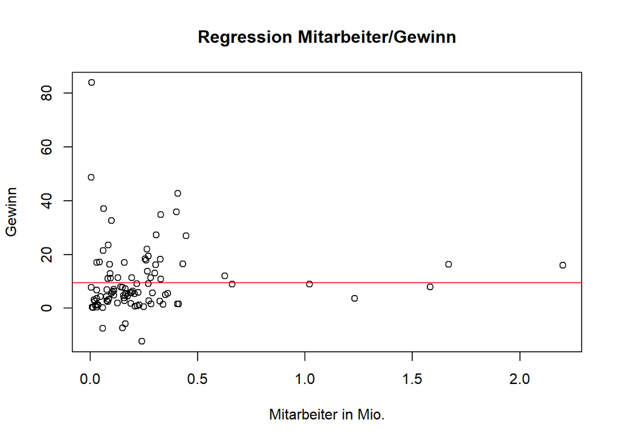

```r
plot(Unternehmensumsätze.df$Mitarbeiter/1000000, Unternehmensumsätze.df$Gewinn, main = "Regression Mitarbeiter/Gewinn", xlab = "Mitarbeiter in Mio.", ylab = "Gewinn")
abline(lm(Unternehmensumsätze.df$Gewinn~Unternehmensumsätze.df$Mitarbeiter), col = "red")
```

**Lorenzkurve angewandt auf die Merkmale “Umsätze” und “Mitarbeiter”**

```r
"ineq" %in% installed.packages()
```

```
## [1] TRUE
```

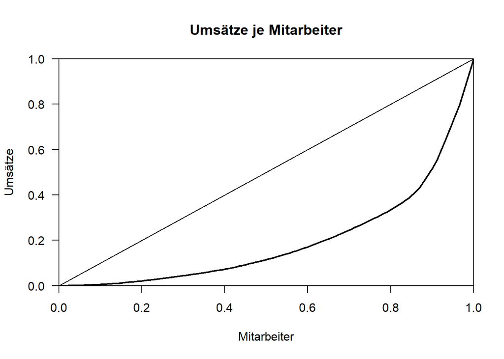

```r
#install.packages("ineq")
library(ineq)

plot(Lc(Unternehmensumsätze.df$Mitarbeiter, Unternehmensumsätze.df$Umsatz), main = "Umsätze je Mitarbeiter", xlab = "Mitarbeiter", ylab = "Umsätze")
```